# HW01

Tarun Viswanath

2024-09-05

```r
library(tidyverse)
```

```r
library(ggplot2)
library(ggthemes)
```

```r
college_score = read_csv("college_scorecard_HW01.csv", na = "NULL")
glimpse(college_score)
```

```
## Rows: 3,059
## Columns: 48
## $ ADM_RATE        <dbl> 0.7160, 0.8854, 0.7367, 0.9799, 0.7890, NA, NA, 0.9680…
## $ AGE_ENTRY       <dbl> 20.28374, 23.60797, 22.72792, 20.13099, 21.13770, 23.0…
## $ AVGFACSAL       <dbl> 8779, 11590, 9820, 7701, 10509, 6523, 8834, 7885, 1109…
## $ CITY            <chr> "Normal", "Birmingham", "Huntsville", "Montgomery", "T…
## $ CONTROL         <dbl> 1, 1, 1, 1, 1, 1, 1, 1, 1, 2, 1, 1, 1, 2, 1, 1, 1, 1, …
## $ COSTT4_A        <dbl> 21924, 26248, 24869, 21938, 31050, 13930, NA, 20621, 3…
## $ ENDOWBEGIN      <dbl> NA, 539858544, 75837207, 111315175, 939393269, 433325,…
## $ FEMALE          <chr> "0.5640301318", "0.6390907397", "0.4763499372", "0.613…
## $ FIRST_GEN       <chr> "0.3658280922", "0.341223671", "0.3101321586", "0.3434…
## $ GRAD_DEBT_MDN   <chr> "31000", "22300", "20705", "31000", "22750", "9766", "…
## $ HBCU            <dbl> 1, 0, 0, 1, 0, 0, 0, 0, 0, 0, 0, 0, 0, 0, 1, 0, 0, 0, …
## $ HSI             <dbl> 0, 0, 0, 0, 0, 0, 0, 0, 0, 0, 0, 0, 0, 0, 0, 0, 0, 0, …
## $ ICLEVEL         <dbl> 1, 1, 1, 1, 1, 2, 1, 1, 1, 1, 2, 2, 2, 1, 2, 2, 2, 2, …
```

[output cut: 35 more lines]

1. City, INSTNM, INSTURL, are STABBR are characters (they should be).

Female, First_Gen, Grad_Debt_MDN, OPEID, PCT_Asian, PCT_Black, PCT_Hispanic, PCT_White and they shouldn’t be.

2. These columns were read in as type character instead of double because they have quotations (““) around the numbers.

```r
college_score2 = read_csv("college_scorecard_HW01.csv",
                          na = c("", "NA", "non-numeric-value"),
                          col_types = cols(
                            CITY = col_character(),
                            INSTNM = col_character(),
                            INSTURL = col_character(),
                            STABBR = col_character(),
                            date = col_date(),
                            .default = col_double()
                          ))
college_score2
```

```
## # A tibble: 3,059 × 48
##    ADM_RATE AGE_ENTRY AVGFACSAL CITY          CONTROL COSTT4_A ENDOWBEGIN FEMALE
##       <dbl>     <dbl>     <dbl> <chr>           <dbl>    <dbl>      <dbl>  <dbl>
##  1    0.716      20.3      8779 Normal              1    21924         NA  0.564
##  2    0.885      23.6     11590 Birmingham          1    26248  539858544  0.639
##  3    0.737      22.7      9820 Huntsville          1    24869   75837207  0.476
##  4    0.980      20.1      7701 Montgomery          1    21938  111315175  0.613
##  5    0.789      21.1     10509 Tuscaloosa          1    31050  939393269  0.615
##  6   NA          23.1      6523 Alexander Ci…       1    13930     433325  0.604
##  7   NA          30.4      8834 Athens              1       NA    4496491  0.705
##  8    0.968      22.2      7885 Montgomery          1    20621   52113787  0.693
##  9    0.712      20.5     11093 Auburn              1    32678  784621493  0.532
## 10    0.659      19.6      7636 Birmingham          2    33920   49403369  0.520
## # ℹ 3,049 more rows
## # ℹ 40 more variables: FIRST_GEN <dbl>, GRAD_DEBT_MDN <dbl>, HBCU <dbl>,
## #   HSI <dbl>, ICLEVEL <dbl>, INSTNM <chr>, INSTURL <chr>,
## #   MD_EARN_WNE_P10 <dbl>, NANTI <dbl>, OPEID <dbl>, PCIP13 <dbl>,
## #   PCIP14 <dbl>, PCIP27 <dbl>, PCIP52 <dbl>, PCT_ASIAN <dbl>, PCT_BLACK <dbl>,
## #   PCT_HISPANIC <dbl>, PCT_WHITE <dbl>, PCTPELL <dbl>, PFTFAC <dbl>,
## #   PREDDEG <dbl>, RELAFFIL <dbl>, SAT_AVG <dbl>, SCH_DEG <dbl>, …
```

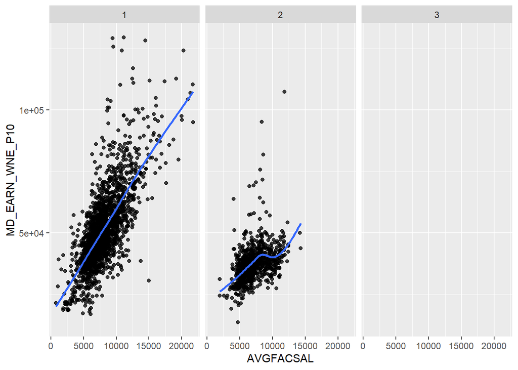

```r
ggplot(college_score2, aes(x = AVGFACSAL, y = MD_EARN_WNE_P10)) + geom_point(alpha = .75) + geom_smooth(se = FALSE) + facet_wrap(~ ICLEVEL)
```

2. Based on the plots, ICLEVEL 1 (Public Four-Year University) have higher median earnings for working students ten years after initial enrollments over ICLEVEL 2 (Community College) when there are higher faculty salaries. As we can see in the graphs, there is more of a positive, linear relationship between faculty salary and median earnings in ICLEVEL1. This may be attributed to the fact that community colleges cannot afford to pay their faculty more, so there isn’t a lot of data to determine the relationship in ICLEVEL 2.
3. Because there is so much data, the mgcv::gam() smoothing method was used by geom_smooth. It uses the GAM (Generalized Additive Model), which is better at handling large datasets over other, more simpler smoothing methods.
4. There is no data in the ICLEVEL 3 plot because so much of the data is missing for colleges that are considered ICLEVEL 3.

```r
ICLEVEL1_data = subset(college_score2, ICLEVEL ==1)

ICLEVEL1relationship = lm(MD_EARN_WNE_P10 ~ AVGFACSAL, data = ICLEVEL1_data)
summary(ICLEVEL1relationship)
```

```
##
## Call:
## lm(formula = MD_EARN_WNE_P10 ~ AVGFACSAL, data = ICLEVEL1_data)
##
## Residuals:
##    Min     1Q Median     3Q    Max
## -50778  -6383  -1389   5568  71709
##
## Coefficients:
##              Estimate Std. Error t value Pr(>|t|)
## (Intercept) 1.683e+04  8.076e+02   20.84   <2e-16 ***
## AVGFACSAL   4.312e+00  9.502e-02   45.38   <2e-16 ***
## ---
## Signif. codes:  0 '***' 0.001 '**' 0.01 '*' 0.05 '.' 0.1 ' ' 1
##
## Residual standard error: 10810 on 1861 degrees of freedom
##   (98 observations deleted due to missingness)
## Multiple R-squared:  0.5253, Adjusted R-squared:  0.525
## F-statistic:  2059 on 1 and 1861 DF,  p-value: < 2.2e-16
```

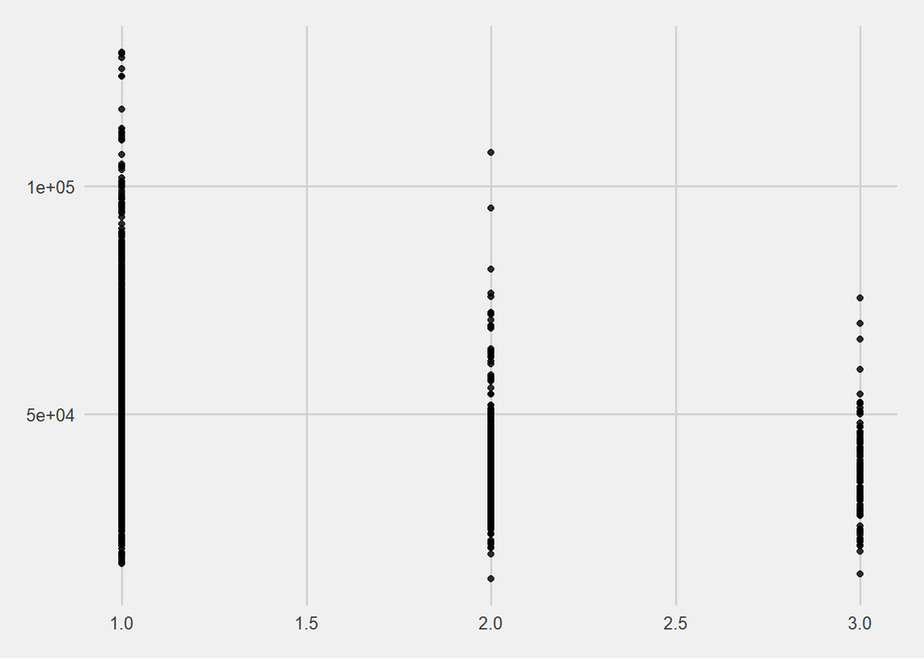

```r
ggplot(college_score2, aes(x = ICLEVEL, y = MD_EARN_WNE_P10)) +
geom_point(alpha = .8) +
geom_smooth(se = FALSE) + ggthemes::theme_fivethirtyeight()
```

b. The plot shows that the as the level of the institution goes down, so does the median earnings of students ten years after enrollment.

```r
MD_EARN_WNE_P10_logged = log(college_score2$MD_EARN_WNE_P10)

loggedICLEVELrelationship = aov(MD_EARN_WNE_P10_logged ~ ICLEVEL, data = college_score2)
```

```r
broom::tidy(loggedICLEVELrelationship)
```

```
## # A tibble: 2 × 6
##   term         df sumsq  meansq statistic    p.value
##   <chr>     <dbl> <dbl>   <dbl>     <dbl>      <dbl>
## 1 ICLEVEL       1  56.1 56.1         755.  5.40e-148
## 2 Residuals  2910 216.   0.0743       NA  NA
```

We would want to look at the log of mean earnings instead of the un-logged values because we want less skewness in data (which lets us handle outliers).

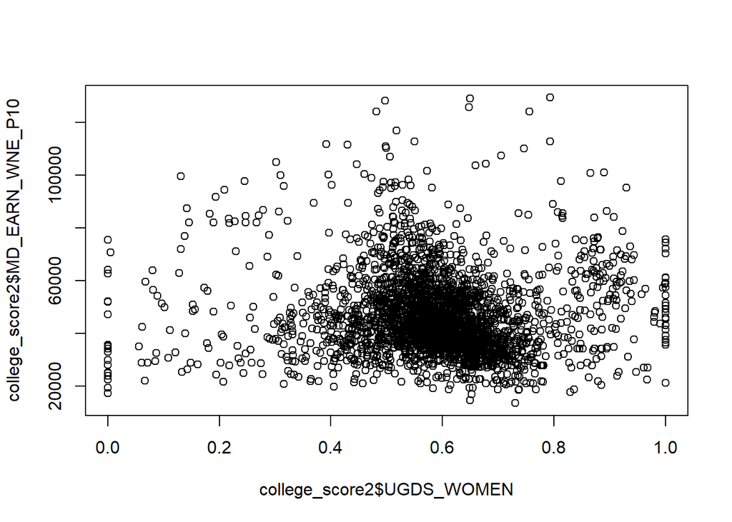

```r
plot(college_score2$UGDS_WOMEN, college_score2$MD_EARN_WNE_P10)
```

2. How does the Percentage of Women Undergraduates affect the median earnings of working students ten years after enrollment?

```r
zerohundred = college_score2 %>%
  filter(UGDS_WOMEN %in% c(0, 100)) %>%
  select(INSTNM, INSTURL, RELAFFIL, UGDS_WOMEN) %>%
  arrange(UGDS_WOMEN, INSTNM)

zerohundred
```

```
## # A tibble: 46 × 4
##    INSTNM                                            INSTURL RELAFFIL UGDS_WOMEN
##    <chr>                                             <chr>      <dbl>      <dbl>
##  1 Bais Medrash Toras Chesed                         www.bm…       NA          0
##  2 Be'er Yaakov Talmudic Seminary                    www.by…       NA          0
##  3 Beis Medrash Heichal Dovid                        www.he…       80          0
##  4 Beth Medrash Govoha                               yeshiv…       NA          0
##  5 Beth Medrash Meor Yitzchok                        https:…       NA          0
##  6 Central Yeshiva Tomchei Tmimim Lubavitz           https:…       NA          0
##  7 Congregation Talmidei Mesivta Tiferes Shmiel Ale… yeshiv…       NA          0
##  8 Kehilath Yakov Rabbinical Seminary                kehila…       80          0
##  9 Machzikei Hadath Rabbinical College               https:…       NA          0
## 10 Mesivta Torah Vodaath Rabbinical Seminary         indepe…       80          0
## # ℹ 36 more rows
```

I’ve noticed that most of the schools are Jewish or at least religious.

```r
tenninety = college_score2 %>%
  filter(UGDS_WOMEN > .10 & UGDS_WOMEN < .90) %>%
  select(INSTNM, UGDS_WOMEN, MD_EARN_WNE_P10) %>%
  arrange(UGDS_WOMEN, INSTNM)
```

```r
head(tenninety)
```

```
## # A tibble: 6 × 3
##   INSTNM                                 UGDS_WOMEN MD_EARN_WNE_P10
##   <chr>                                       <dbl>           <dbl>
## 1 Thaddeus Stevens College of Technology      0.102           49961
## 2 Western Maricopa Education Center           0.107              NA
## 3 Palo Verde College                          0.108           30773
## 4 Rosedale Technical College                  0.112           41351
## 5 University of Fort Lauderdale               0.118              NA
## 6 Emily Griffith Technical College            0.122           32756
```

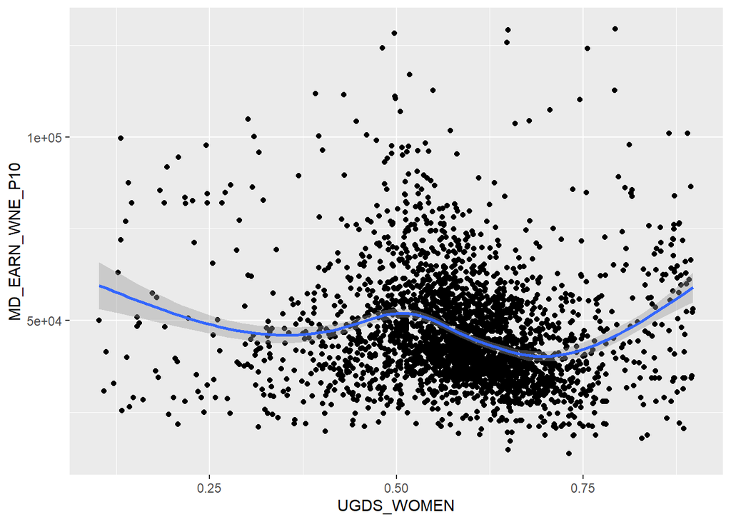

```r
ggplot(tenninety, aes(x = UGDS_WOMEN, y = MD_EARN_WNE_P10)) + geom_point() + geom_smooth()
```

5. I notice that there is a large concentration of undergraduate women making up 50-75% of a school’s population. There isn’t much of a connection between percentage of undergraduate women and median earnings of working students ten years after initial enrollment, so that might need to be studied further.

```r
number_six_model = lm(MD_EARN_WNE_P10 ~ UGDS_WOMEN, data = tenninety)

summary(number_six_model)
```

```
##
## Call:
## lm(formula = MD_EARN_WNE_P10 ~ UGDS_WOMEN, data = tenninety)
##
## Residuals:
##    Min     1Q Median     3Q    Max
## -30668  -9809  -3186   6836  86240
##
## Coefficients:
##             Estimate Std. Error t value Pr(>|t|)
## (Intercept)    55558       1436  38.704  < 2e-16 ***
## UGDS_WOMEN    -15577       2404  -6.479 1.09e-10 ***
## ---
## Signif. codes:  0 '***' 0.001 '**' 0.01 '*' 0.05 '.' 0.1 ' ' 1
##
## Residual standard error: 15010 on 2803 degrees of freedom
##   (108 observations deleted due to missingness)
## Multiple R-squared:  0.01476,    Adjusted R-squared:  0.0144
## F-statistic: 41.98 on 1 and 2803 DF,  p-value: 1.086e-10
```

```r
race_data = college_score2 %>%
  select(UGDS_AIAN, UGDS_ASIAN, UGDS_BLACK, UGDS_HISP, UGDS_NHPI, UGDS_NRA, UGDS_UNKN, UGDS_WHITE, MD_EARN_WNE_P10) %>%
  pivot_longer(
    cols = starts_with("UGDS_"),
      names_to = "Race/Ethnicity",
      values_to = "Median_Earnings") %>%
    filter(complete.cases(.))
```

```r
ninety_perc = race_data %>%
  filter(`Race/Ethnicity` != "UGDS_WHITE") %>%
  summarize(ninety_perc = quantile(college_score2$MD_EARN_WNE_P10, 0.90, na.rm = TRUE)) %>%
  pull(ninety_perc)
```

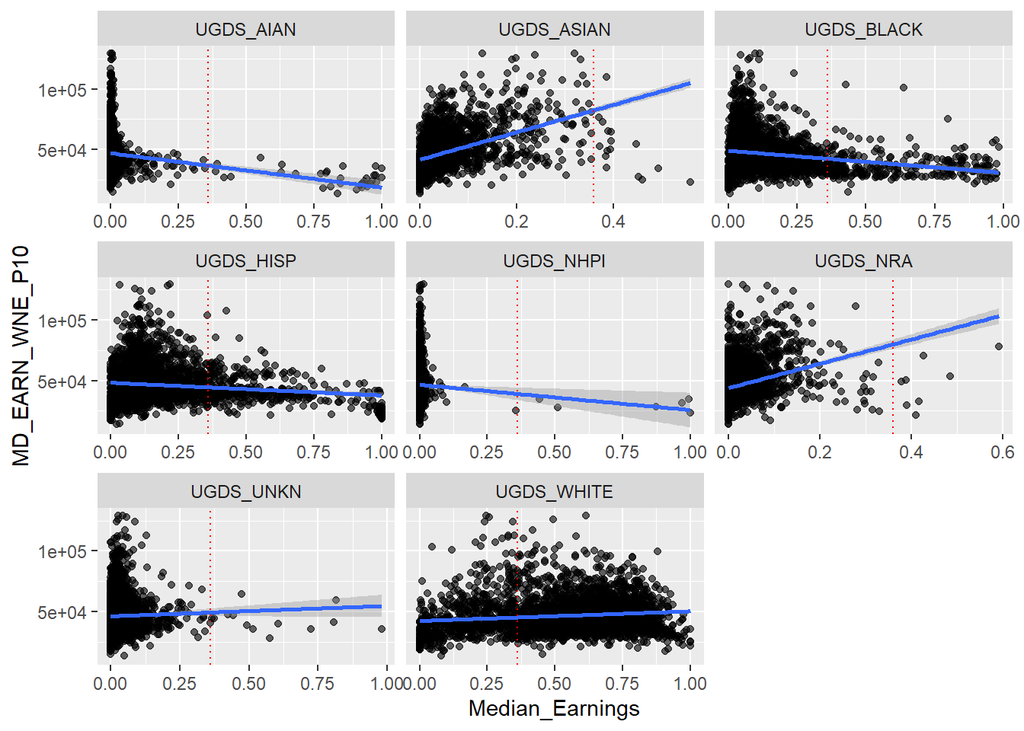

```r
ggplot(race_data, aes(x = Median_Earnings, y = MD_EARN_WNE_P10)) + geom_point(alpha = 0.6) +
  geom_smooth(method = "lm") + facet_wrap(~ `Race/Ethnicity`, scales = "free_x") + geom_vline(xintercept = .36, color = "red", lty = 3)
```

2. How does the undergraduate percentage of different races/ethnicities affect the median earnings of working students ten years after initial enrollment?

Based on the plot, we can see that schools with a higher undergraduate asian population tend to have higher median earnings. Undergraduate white population is very consistent, but might have slightly higher median earnings when it has more people. Meanwhile, black, hispanic, and native american student populations tend to have slightly reduced median earnings when there are more undergraduate students.

3. Using a linear smoother might show misleading evidence, as it tends to impose a linear relationship that may appear stronger than it really is. This could lead to misrepresentations of the data and racist assumptions (in terms of this plot). Using a non-linear smoother does a better job at representing the true nature of the data and is good to use with large datasets. I’d recommend using the non-linear smoother in this data set if I wanted to “prove a point.” Trying to prove a point by using a linear smoother in this data set would lead to innacurate conclusions. The non-linear smoother is much better at capturing complex relationships, as most of these should be in this plot.

```r
eighta_data = college_score2 %>%
  filter(ICLEVEL == 1) %>%
  filter(!is.na(COSTT4_A) & !is.na(GRAD_DEBT_MDN)) %>%
  filter(!str_detect(OPEID, "......00"))
```

```r
class(eighta_data$MD_EARN_WNE_P10)
```

```
## [1] "numeric"
```

```r
class(eighta_data$GRAD_DEBT_MDN)
```

```
## [1] "numeric"
```

```r
eighta_data = eighta_data %>%
  mutate(GRAD_DEBT_MDN = as.numeric(GRAD_DEBT_MDN))
```

```r
eighta_data = eighta_data %>%
  mutate(DCR = AVGFACSAL/GRAD_DEBT_MDN)
```

```r
eighta_data
```

```
## # A tibble: 1,776 × 49
##    ADM_RATE AGE_ENTRY AVGFACSAL CITY       CONTROL COSTT4_A ENDOWBEGIN FEMALE
##       <dbl>     <dbl>     <dbl> <chr>        <dbl>    <dbl>      <dbl>  <dbl>
##  1    0.716      20.3      8779 Normal           1    21924         NA  0.564
##  2    0.885      23.6     11590 Birmingham       1    26248  539858544  0.639
##  3    0.737      22.7      9820 Huntsville       1    24869   75837207  0.476
##  4    0.980      20.1      7701 Montgomery       1    21938  111315175  0.613
##  5    0.789      21.1     10509 Tuscaloosa       1    31050  939393269  0.615
##  6    0.968      22.2      7885 Montgomery       1    20621   52113787  0.693
##  7    0.712      20.5     11093 Auburn           1    32678  784621493  0.532
##  8    0.659      19.6      7636 Birmingham       2    33920   49403369  0.520
##  9    0.646      28.3      6271 Montgomery       2    36457   17838794  0.639
## 10    0.938      31.3      6644 Birmingham       2    31202         NA  0.814
## # ℹ 1,766 more rows
## # ℹ 41 more variables: FIRST_GEN <dbl>, GRAD_DEBT_MDN <dbl>, HBCU <dbl>,
## #   HSI <dbl>, ICLEVEL <dbl>, INSTNM <chr>, INSTURL <chr>,
## #   MD_EARN_WNE_P10 <dbl>, NANTI <dbl>, OPEID <dbl>, PCIP13 <dbl>,
## #   PCIP14 <dbl>, PCIP27 <dbl>, PCIP52 <dbl>, PCT_ASIAN <dbl>, PCT_BLACK <dbl>,
## #   PCT_HISPANIC <dbl>, PCT_WHITE <dbl>, PCTPELL <dbl>, PFTFAC <dbl>,
## #   PREDDEG <dbl>, RELAFFIL <dbl>, SAT_AVG <dbl>, SCH_DEG <dbl>, …
```

```r
eighta_data = eighta_data %>%
  arrange(DCR) %>%
  mutate(rank = row_number()) %>%
  mutate(rank = dense_rank(DCR))

eighta_data
```

```
## # A tibble: 1,776 × 50
##    ADM_RATE AGE_ENTRY AVGFACSAL CITY          CONTROL COSTT4_A ENDOWBEGIN FEMALE
##       <dbl>     <dbl>     <dbl> <chr>           <dbl>    <dbl>      <dbl>  <dbl>
##  1   NA          34.5      1923 Circleville         2    33707    5931729  0.638
##  2   NA          39.9       801 Trujillo Alto       2    11216         NA  0.437
##  3    0.954      27.3      1114 Fayetteville        2    17237      31462  0.526
##  4    0.674      23.9      1167 Springdale          2    28210         NA  0.376
##  5    0.474      38.4      3458 Lithonia            2     9680    1124736  0.343
##  6    0.604      33.5      4302 Boca Raton          2    37668         NA  0.552
##  7   NA          33.7      4977 Indianapolis        2    25074         NA  0.698
##  8    0.500      30.2      3339 McKenzie            2    31078   11601662  0.584
##  9   NA          23.4      3385 Arlington           2    27387         NA  0.364
## 10   NA          23.9      3736 Rock Hill           2    13457     425762  0.289
## # ℹ 1,766 more rows
## # ℹ 42 more variables: FIRST_GEN <dbl>, GRAD_DEBT_MDN <dbl>, HBCU <dbl>,
## #   HSI <dbl>, ICLEVEL <dbl>, INSTNM <chr>, INSTURL <chr>,
## #   MD_EARN_WNE_P10 <dbl>, NANTI <dbl>, OPEID <dbl>, PCIP13 <dbl>,
## #   PCIP14 <dbl>, PCIP27 <dbl>, PCIP52 <dbl>, PCT_ASIAN <dbl>, PCT_BLACK <dbl>,
## #   PCT_HISPANIC <dbl>, PCT_WHITE <dbl>, PCTPELL <dbl>, PFTFAC <dbl>,
## #   PREDDEG <dbl>, RELAFFIL <dbl>, SAT_AVG <dbl>, SCH_DEG <dbl>, …
```

```r
top_five = eighta_data %>%
  slice_head(n = 5) %>%
  select(rank, INSTNM, DCR, COSTT4_A, GRAD_DEBT_MDN, MD_EARN_WNE_P10)

top_five
```

```
## # A tibble: 5 × 6
##    rank INSTNM                        DCR COSTT4_A GRAD_DEBT_MDN MD_EARN_WNE_P10
##   <int> <chr>                       <dbl>    <dbl>         <dbl>           <dbl>
## 1     1 Ohio Christian University  0.0650    33707         29579           40968
## 2     2 Universidad Teologica del… 0.0665    11216         12050           21480
## 3     3 Manna University           0.0828    17237         13450              NA
## 4     4 Ecclesia College           0.0896    28210         13019           39184
## 5     5 Luther Rice College & Sem… 0.101      9680         34153           49700
```

```r
bottom_five = eighta_data %>%
  filter(!is.na(DCR)) %>%
  slice_tail(n = 5) %>%
  select(rank, INSTNM, DCR, COSTT4_A, GRAD_DEBT_MDN, MD_EARN_WNE_P10)

bottom_five
```

```
## # A tibble: 5 × 6
##    rank INSTNM                   DCR COSTT4_A GRAD_DEBT_MDN MD_EARN_WNE_P10
##   <int> <chr>                  <dbl>    <dbl>         <dbl>           <dbl>
## 1  1756 San Diego Mesa College  1.94    12900          4725           43015
## 2  1757 Rio Hondo College       2.00    12763          5500           41919
## 3  1758 Princeton University    2.10    68044         10320          110433
## 4  1759 Berea College           2.30    55656          3591           40738
## 5  1760 Laredo College          2.35    11346          2959           33540
```

```r
AU = eighta_data %>%
  filter(INSTNM == "American University") %>%
  select(rank, INSTNM, DCR, COSTT4_A, GRAD_DEBT_MDN, MD_EARN_WNE_P10)

AU
```

```
## # A tibble: 1 × 6
##    rank INSTNM                DCR COSTT4_A GRAD_DEBT_MDN MD_EARN_WNE_P10
##   <int> <chr>               <dbl>    <dbl>         <dbl>           <dbl>
## 1  1427 American University 0.544    56065         22750           75354
```

American University’s rank is 1427 and their DCR is 0.5444835

#World Bank

```r
country_income = read_csv("wb_country_income_classification_2023.csv", na = "NULL")
fertility = read_csv("wb_fertility_2022.csv", na = "NULL")
life_exp = read_csv("wb_life_exp_2022.csv", na = "NULL")
wb_pop = read_csv("wb_pop_2023.csv", na = "NULL")
head(country_income)
```

```
## # A tibble: 6 × 5
##   Economy        Code  Region                  `Income group` `Lending category`
##   <chr>          <chr> <chr>                   <chr>          <chr>
## 1 Afghanistan    AFG   South Asia              Low income     "IDA"
## 2 Albania        ALB   Europe & Central Asia   Upper middle … "IBRD"
## 3 Algeria        DZA   Middle East & North Af… Upper middle … "IBRD"
## 4 American Samoa ASM   East Asia & Pacific     High income    ""
## 5 Andorra        AND   Europe & Central Asia   High income    ""
## 6 Angola         AGO   Sub-Saharan Africa      Lower middle … "IBRD"
```

```r
head(fertility)
```

```
## # A tibble: 6 × 68
##   `Series Name`      `Series Code` `Country Name` `Country Code` `1960 [YR1960]`
##   <chr>              <chr>         <chr>          <chr>          <chr>
## 1 Fertility rate, t… SP.DYN.TFRT.… Afghanistan    AFG            7.282
## 2 Fertility rate, t… SP.DYN.TFRT.… Albania        ALB            6.455
## 3 Fertility rate, t… SP.DYN.TFRT.… Algeria        DZA            7.503
## 4 Fertility rate, t… SP.DYN.TFRT.… American Samoa ASM            ..
## 5 Fertility rate, t… SP.DYN.TFRT.… Andorra        AND            ..
## 6 Fertility rate, t… SP.DYN.TFRT.… Angola         AGO            6.708
## # ℹ 63 more variables: `1961 [YR1961]` <chr>, `1962 [YR1962]` <chr>,
## #   `1963 [YR1963]` <chr>, `1964 [YR1964]` <chr>, `1965 [YR1965]` <chr>,
## #   `1966 [YR1966]` <chr>, `1967 [YR1967]` <chr>, `1968 [YR1968]` <chr>,
## #   `1969 [YR1969]` <chr>, `1970 [YR1970]` <chr>, `1971 [YR1971]` <chr>,
## #   `1972 [YR1972]` <chr>, `1973 [YR1973]` <chr>, `1974 [YR1974]` <chr>,
## #   `1975 [YR1975]` <chr>, `1976 [YR1976]` <chr>, `1977 [YR1977]` <chr>,
## #   `1978 [YR1978]` <chr>, `1979 [YR1979]` <chr>, `1980 [YR1980]` <chr>, …
```

```r
head(life_exp)
```

```
## # A tibble: 6 × 68
##   `Series Name`      `Series Code` `Country Name` `Country Code` `1960 [YR1960]`
##   <chr>              <chr>         <chr>          <chr>          <chr>
## 1 Life expectancy a… SP.DYN.LE00.… Afghanistan    AFG            32.535
## 2 Life expectancy a… SP.DYN.LE00.… Albania        ALB            54.439
## 3 Life expectancy a… SP.DYN.LE00.… Algeria        DZA            40.532
## 4 Life expectancy a… SP.DYN.LE00.… American Samoa ASM            ..
## 5 Life expectancy a… SP.DYN.LE00.… Andorra        AND            ..
## 6 Life expectancy a… SP.DYN.LE00.… Angola         AGO            38.211
## # ℹ 63 more variables: `1961 [YR1961]` <chr>, `1962 [YR1962]` <chr>,
## #   `1963 [YR1963]` <chr>, `1964 [YR1964]` <chr>, `1965 [YR1965]` <chr>,
## #   `1966 [YR1966]` <chr>, `1967 [YR1967]` <chr>, `1968 [YR1968]` <chr>,
## #   `1969 [YR1969]` <chr>, `1970 [YR1970]` <chr>, `1971 [YR1971]` <chr>,
## #   `1972 [YR1972]` <chr>, `1973 [YR1973]` <chr>, `1974 [YR1974]` <chr>,
## #   `1975 [YR1975]` <chr>, `1976 [YR1976]` <chr>, `1977 [YR1977]` <chr>,
## #   `1978 [YR1978]` <chr>, `1979 [YR1979]` <chr>, `1980 [YR1980]` <chr>, …
```

```r
head(wb_pop)
```

```
## # A tibble: 6 × 68
##   `Series Name`     `Series Code` `Country Name` `Country Code` `1960 [YR1960]`
##   <chr>             <chr>         <chr>          <chr>          <chr>
## 1 Population, total SP.POP.TOTL   Afghanistan    AFG            8622466
## 2 Population, total SP.POP.TOTL   Albania        ALB            1608800
## 3 Population, total SP.POP.TOTL   Algeria        DZA            11394307
## 4 Population, total SP.POP.TOTL   American Samoa ASM            20085
## 5 Population, total SP.POP.TOTL   Andorra        AND            9443
## 6 Population, total SP.POP.TOTL   Angola         AGO            5357195
## # ℹ 63 more variables: `1961 [YR1961]` <chr>, `1962 [YR1962]` <chr>,
## #   `1963 [YR1963]` <chr>, `1964 [YR1964]` <chr>, `1965 [YR1965]` <chr>,
## #   `1966 [YR1966]` <chr>, `1967 [YR1967]` <chr>, `1968 [YR1968]` <chr>,
## #   `1969 [YR1969]` <chr>, `1970 [YR1970]` <chr>, `1971 [YR1971]` <chr>,
## #   `1972 [YR1972]` <chr>, `1973 [YR1973]` <chr>, `1974 [YR1974]` <chr>,
## #   `1975 [YR1975]` <chr>, `1976 [YR1976]` <chr>, `1977 [YR1977]` <chr>,
## #   `1978 [YR1978]` <chr>, `1979 [YR1979]` <chr>, `1980 [YR1980]` <chr>, …
```

```r
#fertility changes
fertility = fertility %>%
  mutate(across(5:68, ~ as.double(.)))
fertility
```

```
## # A tibble: 271 × 68
##    `Series Name`     `Series Code` `Country Name` `Country Code` `1960 [YR1960]`
##    <chr>             <chr>         <chr>          <chr>                    <dbl>
##  1 Fertility rate, … SP.DYN.TFRT.… Afghanistan    AFG                       7.28
##  2 Fertility rate, … SP.DYN.TFRT.… Albania        ALB                       6.46
##  3 Fertility rate, … SP.DYN.TFRT.… Algeria        DZA                       7.50
##  4 Fertility rate, … SP.DYN.TFRT.… American Samoa ASM                      NA
##  5 Fertility rate, … SP.DYN.TFRT.… Andorra        AND                      NA
##  6 Fertility rate, … SP.DYN.TFRT.… Angola         AGO                       6.71
##  7 Fertility rate, … SP.DYN.TFRT.… Antigua and B… ATG                       4.60
##  8 Fertility rate, … SP.DYN.TFRT.… Argentina      ARG                       3.08
##  9 Fertility rate, … SP.DYN.TFRT.… Armenia        ARM                       4.79
## 10 Fertility rate, … SP.DYN.TFRT.… Aruba          ABW                       4.82
## # ℹ 261 more rows
## # ℹ 63 more variables: `1961 [YR1961]` <dbl>, `1962 [YR1962]` <dbl>,
## #   `1963 [YR1963]` <dbl>, `1964 [YR1964]` <dbl>, `1965 [YR1965]` <dbl>,
## #   `1966 [YR1966]` <dbl>, `1967 [YR1967]` <dbl>, `1968 [YR1968]` <dbl>,
## #   `1969 [YR1969]` <dbl>, `1970 [YR1970]` <dbl>, `1971 [YR1971]` <dbl>,
## #   `1972 [YR1972]` <dbl>, `1973 [YR1973]` <dbl>, `1974 [YR1974]` <dbl>,
## #   `1975 [YR1975]` <dbl>, `1976 [YR1976]` <dbl>, `1977 [YR1977]` <dbl>, …
```

```r
#life_exp changes
life_exp = life_exp %>%
   mutate(across(5:68, ~ as.double(.)))
life_exp
```

```
## # A tibble: 271 × 68
##    `Series Name`     `Series Code` `Country Name` `Country Code` `1960 [YR1960]`
##    <chr>             <chr>         <chr>          <chr>                    <dbl>
##  1 Life expectancy … SP.DYN.LE00.… Afghanistan    AFG                       32.5
##  2 Life expectancy … SP.DYN.LE00.… Albania        ALB                       54.4
##  3 Life expectancy … SP.DYN.LE00.… Algeria        DZA                       40.5
##  4 Life expectancy … SP.DYN.LE00.… American Samoa ASM                       NA
##  5 Life expectancy … SP.DYN.LE00.… Andorra        AND                       NA
##  6 Life expectancy … SP.DYN.LE00.… Angola         AGO                       38.2
##  7 Life expectancy … SP.DYN.LE00.… Antigua and B… ATG                       61.6
##  8 Life expectancy … SP.DYN.LE00.… Argentina      ARG                       64.0
##  9 Life expectancy … SP.DYN.LE00.… Armenia        ARM                       61.4
## 10 Life expectancy … SP.DYN.LE00.… Aruba          ABW                       64.2
## # ℹ 261 more rows
## # ℹ 63 more variables: `1961 [YR1961]` <dbl>, `1962 [YR1962]` <dbl>,
## #   `1963 [YR1963]` <dbl>, `1964 [YR1964]` <dbl>, `1965 [YR1965]` <dbl>,
## #   `1966 [YR1966]` <dbl>, `1967 [YR1967]` <dbl>, `1968 [YR1968]` <dbl>,
## #   `1969 [YR1969]` <dbl>, `1970 [YR1970]` <dbl>, `1971 [YR1971]` <dbl>,
## #   `1972 [YR1972]` <dbl>, `1973 [YR1973]` <dbl>, `1974 [YR1974]` <dbl>,
## #   `1975 [YR1975]` <dbl>, `1976 [YR1976]` <dbl>, `1977 [YR1977]` <dbl>, …
```

```r
#wb_pop changes
wb_pop = wb_pop %>%
  mutate(across(5:68, ~ as.double(.)))
wb_pop
```

```
## # A tibble: 271 × 68
##    `Series Name`     `Series Code` `Country Name` `Country Code` `1960 [YR1960]`
##    <chr>             <chr>         <chr>          <chr>                    <dbl>
##  1 Population, total SP.POP.TOTL   Afghanistan    AFG                    8622466
##  2 Population, total SP.POP.TOTL   Albania        ALB                    1608800
##  3 Population, total SP.POP.TOTL   Algeria        DZA                   11394307
##  4 Population, total SP.POP.TOTL   American Samoa ASM                      20085
##  5 Population, total SP.POP.TOTL   Andorra        AND                       9443
##  6 Population, total SP.POP.TOTL   Angola         AGO                    5357195
##  7 Population, total SP.POP.TOTL   Antigua and B… ATG                      55342
##  8 Population, total SP.POP.TOTL   Argentina      ARG                   20349744
##  9 Population, total SP.POP.TOTL   Armenia        ARM                    1904148
## 10 Population, total SP.POP.TOTL   Aruba          ABW                      54608
## # ℹ 261 more rows
## # ℹ 63 more variables: `1961 [YR1961]` <dbl>, `1962 [YR1962]` <dbl>,
## #   `1963 [YR1963]` <dbl>, `1964 [YR1964]` <dbl>, `1965 [YR1965]` <dbl>,
## #   `1966 [YR1966]` <dbl>, `1967 [YR1967]` <dbl>, `1968 [YR1968]` <dbl>,
## #   `1969 [YR1969]` <dbl>, `1970 [YR1970]` <dbl>, `1971 [YR1971]` <dbl>,
## #   `1972 [YR1972]` <dbl>, `1973 [YR1973]` <dbl>, `1974 [YR1974]` <dbl>,
## #   `1975 [YR1975]` <dbl>, `1976 [YR1976]` <dbl>, `1977 [YR1977]` <dbl>, …
```

```r
problems(country_income)
```

```
## # A tibble: 0 × 5
## # ℹ 5 variables: row <int>, col <int>, expected <chr>, actual <chr>, file <chr>
```

```r
problems(fertility)
problems(life_exp)
problems(wb_pop)
```

```r
country_income = country_income %>%
  rename(CC = Code)
wb_pop = wb_pop %>%
  rename(CC = `Country Code`)
fertility = fertility %>%
  rename(CC = `Country Code`)
life_exp = life_exp %>%
  rename(CC = `Country Code`)
```

```r
country_not_in_pop = anti_join(country_income, wb_pop, by = "CC")

pop_not_in_country = anti_join(wb_pop, country_income, by = "CC")

country_not_in_pop
```

```
## # A tibble: 1 × 5
##   Economy       CC    Region              `Income group` `Lending category`
##   <chr>         <chr> <chr>               <chr>          <chr>
## 1 Taiwan, China TWN   East Asia & Pacific High income    ""
```

```r
pop_not_in_country
```

```
## # A tibble: 1 × 68
##   `Series Name`     `Series Code` `Country Name` CC    `1960 [YR1960]`
##   <chr>             <chr>         <chr>          <chr>           <dbl>
## 1 Population, total SP.POP.TOTL   Not classified INX                NA
## # ℹ 63 more variables: `1961 [YR1961]` <dbl>, `1962 [YR1962]` <dbl>,
## #   `1963 [YR1963]` <dbl>, `1964 [YR1964]` <dbl>, `1965 [YR1965]` <dbl>,
## #   `1966 [YR1966]` <dbl>, `1967 [YR1967]` <dbl>, `1968 [YR1968]` <dbl>,
## #   `1969 [YR1969]` <dbl>, `1970 [YR1970]` <dbl>, `1971 [YR1971]` <dbl>,
## #   `1972 [YR1972]` <dbl>, `1973 [YR1973]` <dbl>, `1974 [YR1974]` <dbl>,
## #   `1975 [YR1975]` <dbl>, `1976 [YR1976]` <dbl>, `1977 [YR1977]` <dbl>,
## #   `1978 [YR1978]` <dbl>, `1979 [YR1979]` <dbl>, `1980 [YR1980]` <dbl>, …
```

```r
#fertility tidy
fertility_tidy = fertility %>%
  rename_with(~ str_remove(., "\\s\\[.*\\]")) %>%
  pivot_longer(
    cols = matches("^[12]"),
    names_to = "Year"
  ) %>%
  select(-c(1:2)) %>%
  rename(fertility_rate = value)

head(fertility_tidy)
```

```
## # A tibble: 6 × 4
##   `Country Name` CC    Year  fertility_rate
##   <chr>          <chr> <chr>          <dbl>
## 1 Afghanistan    AFG   1960            7.28
## 2 Afghanistan    AFG   1961            7.28
## 3 Afghanistan    AFG   1962            7.29
## 4 Afghanistan    AFG   1963            7.30
## 5 Afghanistan    AFG   1964            7.30
## 6 Afghanistan    AFG   1965            7.30
```

```r
#life_exp tidy
life_exp_tidy = life_exp %>%
  rename_with(~ str_remove(., "\\s\\[.*\\]")) %>%
  pivot_longer(
    cols = matches("^[12]"),
    names_to = "Year"
  ) %>%
  select(-c(1:2)) %>%
  rename(fertility_rate = value)

head(fertility_tidy)
```

```
## # A tibble: 6 × 4
##   `Country Name` CC    Year  fertility_rate
##   <chr>          <chr> <chr>          <dbl>
## 1 Afghanistan    AFG   1960            7.28
## 2 Afghanistan    AFG   1961            7.28
## 3 Afghanistan    AFG   1962            7.29
## 4 Afghanistan    AFG   1963            7.30
## 5 Afghanistan    AFG   1964            7.30
## 6 Afghanistan    AFG   1965            7.30
```

```r
#wb_pop tidy
wb_pop_tidy = wb_pop %>%
  rename_with(~ str_remove(., "\\s\\[.*\\]")) %>%
  pivot_longer(
  cols = matches("^[12]"),
    names_to = "Year"
) %>%
  select(-c(1:2)) %>%
  rename(population = value)

head(wb_pop_tidy)
```

```
## # A tibble: 6 × 4
##   `Country Name` CC    Year  population
##   <chr>          <chr> <chr>      <dbl>
## 1 Afghanistan    AFG   1960     8622466
## 2 Afghanistan    AFG   1961     8790140
## 3 Afghanistan    AFG   1962     8969047
## 4 Afghanistan    AFG   1963     9157465
## 5 Afghanistan    AFG   1964     9355514
## 6 Afghanistan    AFG   1965     9565147
```

```r
#fertility tidy
fertility_tidy$Year = as.numeric(fertility_tidy$Year)

glimpse(fertility_tidy)
```

```
## Rows: 17,344
## Columns: 4
## $ `Country Name` <chr> "Afghanistan", "Afghanistan", "Afghanistan", "Afghanist…
## $ CC             <chr> "AFG", "AFG", "AFG", "AFG", "AFG", "AFG", "AFG", "AFG",…
## $ Year           <dbl> 1960, 1961, 1962, 1963, 1964, 1965, 1966, 1967, 1968, 1…
## $ fertility_rate <dbl> 7.282, 7.284, 7.292, 7.302, 7.304, 7.305, 7.320, 7.339,…
```

```r
#life_exp tidy
life_exp_tidy$Year = as.numeric(life_exp_tidy$Year)

glimpse(life_exp_tidy)
```

```
## Rows: 17,344
## Columns: 4
## $ `Country Name` <chr> "Afghanistan", "Afghanistan", "Afghanistan", "Afghanist…
## $ CC             <chr> "AFG", "AFG", "AFG", "AFG", "AFG", "AFG", "AFG", "AFG",…
## $ Year           <dbl> 1960, 1961, 1962, 1963, 1964, 1965, 1966, 1967, 1968, 1…
## $ fertility_rate <dbl> 32.535, 33.068, 33.547, 34.016, 34.494, 34.953, 35.453,…
```

```r
#wb_pop tidy
wb_pop_tidy$Year = as.numeric(wb_pop_tidy$Year)

glimpse(wb_pop_tidy)
```

```
## Rows: 17,344
## Columns: 4
## $ `Country Name` <chr> "Afghanistan", "Afghanistan", "Afghanistan", "Afghanist…
## $ CC             <chr> "AFG", "AFG", "AFG", "AFG", "AFG", "AFG", "AFG", "AFG",…
## $ Year           <dbl> 1960, 1961, 1962, 1963, 1964, 1965, 1966, 1967, 1968, 1…
## $ population     <dbl> 8622466, 8790140, 8969047, 9157465, 9355514, 9565147, 9…
```

```r
#fertility tidy
fertility_tidy = fertility_tidy %>%
  drop_na()

fertility_tidy
```

```
## # A tibble: 16,137 × 4
##    `Country Name` CC     Year fertility_rate
##    <chr>          <chr> <dbl>          <dbl>
##  1 Afghanistan    AFG    1960           7.28
##  2 Afghanistan    AFG    1961           7.28
##  3 Afghanistan    AFG    1962           7.29
##  4 Afghanistan    AFG    1963           7.30
##  5 Afghanistan    AFG    1964           7.30
##  6 Afghanistan    AFG    1965           7.30
##  7 Afghanistan    AFG    1966           7.32
##  8 Afghanistan    AFG    1967           7.34
##  9 Afghanistan    AFG    1968           7.36
## 10 Afghanistan    AFG    1969           7.39
## # ℹ 16,127 more rows
```

```r
#life_exp tidy
life_exp_tidy = life_exp_tidy %>%
  drop_na()

life_exp_tidy
```

```
## # A tibble: 16,124 × 4
##    `Country Name` CC     Year fertility_rate
##    <chr>          <chr> <dbl>          <dbl>
##  1 Afghanistan    AFG    1960           32.5
##  2 Afghanistan    AFG    1961           33.1
##  3 Afghanistan    AFG    1962           33.5
##  4 Afghanistan    AFG    1963           34.0
##  5 Afghanistan    AFG    1964           34.5
##  6 Afghanistan    AFG    1965           35.0
##  7 Afghanistan    AFG    1966           35.5
##  8 Afghanistan    AFG    1967           35.9
##  9 Afghanistan    AFG    1968           36.4
## 10 Afghanistan    AFG    1969           36.9
## # ℹ 16,114 more rows
```

```r
#wb_pop tidy
wb_pop_tidy = wb_pop_tidy %>%
  drop_na()

wb_pop_tidy
```

```
## # A tibble: 16,930 × 4
##    `Country Name` CC     Year population
##    <chr>          <chr> <dbl>      <dbl>
##  1 Afghanistan    AFG    1960    8622466
##  2 Afghanistan    AFG    1961    8790140
##  3 Afghanistan    AFG    1962    8969047
##  4 Afghanistan    AFG    1963    9157465
##  5 Afghanistan    AFG    1964    9355514
##  6 Afghanistan    AFG    1965    9565147
##  7 Afghanistan    AFG    1966    9783147
##  8 Afghanistan    AFG    1967   10010030
##  9 Afghanistan    AFG    1968   10247780
## 10 Afghanistan    AFG    1969   10494489
## # ℹ 16,920 more rows
```

```r
#fertility tidy
tidied_fertility = fertility_tidy
```

```r
#life_exp tidy
tidied_life_exp = life_exp_tidy
```

```r
#wb_pop tidy
tidied_wb_pop = wb_pop_tidy
```

```r
#fertility tidy
count(tidied_fertility)
```

```
## # A tibble: 1 × 1
##       n
##   <int>
## 1 16137
```

```r
head(tidied_fertility)
```

```
## # A tibble: 6 × 4
##   `Country Name` CC     Year fertility_rate
##   <chr>          <chr> <dbl>          <dbl>
## 1 Afghanistan    AFG    1960           7.28
## 2 Afghanistan    AFG    1961           7.28
## 3 Afghanistan    AFG    1962           7.29
## 4 Afghanistan    AFG    1963           7.30
## 5 Afghanistan    AFG    1964           7.30
## 6 Afghanistan    AFG    1965           7.30
```

```r
#life_exp tidy
count(tidied_life_exp)
```

```
## # A tibble: 1 × 1
##       n
##   <int>
## 1 16124
```

```r
head(tidied_life_exp)
```

```
## # A tibble: 6 × 4
##   `Country Name` CC     Year fertility_rate
##   <chr>          <chr> <dbl>          <dbl>
## 1 Afghanistan    AFG    1960           32.5
## 2 Afghanistan    AFG    1961           33.1
## 3 Afghanistan    AFG    1962           33.5
## 4 Afghanistan    AFG    1963           34.0
## 5 Afghanistan    AFG    1964           34.5
## 6 Afghanistan    AFG    1965           35.0
```

```r
#wb_pop tidy
count(tidied_wb_pop)
```

```
## # A tibble: 1 × 1
##       n
##   <int>
## 1 16930
```

```r
head(tidied_life_exp)
```

```
## # A tibble: 6 × 4
##   `Country Name` CC     Year fertility_rate
##   <chr>          <chr> <dbl>          <dbl>
## 1 Afghanistan    AFG    1960           32.5
## 2 Afghanistan    AFG    1961           33.1
## 3 Afghanistan    AFG    1962           33.5
## 4 Afghanistan    AFG    1963           34.0
## 5 Afghanistan    AFG    1964           34.5
## 6 Afghanistan    AFG    1965           35.0
```

```r
fert_life_exp = wb_pop_tidy %>%
  left_join(fertility_tidy, by = c("Country Name", "CC", "Year")) %>%
  left_join(life_exp_tidy, by = c("Country Name", "CC", "Year")) %>%
  rename(fertility_rate = fertility_rate.x) %>%
  rename(life_expectancy = fertility_rate.y)

glimpse(fert_life_exp)
```

```
## Rows: 16,930
## Columns: 6
## $ `Country Name`  <chr> "Afghanistan", "Afghanistan", "Afghanistan", "Afghanis…
## $ CC              <chr> "AFG", "AFG", "AFG", "AFG", "AFG", "AFG", "AFG", "AFG"…
## $ Year            <dbl> 1960, 1961, 1962, 1963, 1964, 1965, 1966, 1967, 1968, …
## $ population      <dbl> 8622466, 8790140, 8969047, 9157465, 9355514, 9565147, …
## $ fertility_rate  <dbl> 7.282, 7.284, 7.292, 7.302, 7.304, 7.305, 7.320, 7.339…
## $ life_expectancy <dbl> 32.535, 33.068, 33.547, 34.016, 34.494, 34.953, 35.453…
```

```r
final_joined_data = fert_life_exp %>%
  left_join(country_income, by = c("CC"))

glimpse(final_joined_data)
```

```
## Rows: 16,930
## Columns: 10
## $ `Country Name`     <chr> "Afghanistan", "Afghanistan", "Afghanistan", "Afgha…
## $ CC                 <chr> "AFG", "AFG", "AFG", "AFG", "AFG", "AFG", "AFG", "A…
## $ Year               <dbl> 1960, 1961, 1962, 1963, 1964, 1965, 1966, 1967, 196…
## $ population         <dbl> 8622466, 8790140, 8969047, 9157465, 9355514, 956514…
## $ fertility_rate     <dbl> 7.282, 7.284, 7.292, 7.302, 7.304, 7.305, 7.320, 7.…
## $ life_expectancy    <dbl> 32.535, 33.068, 33.547, 34.016, 34.494, 34.953, 35.…
## $ Economy            <chr> "Afghanistan", "Afghanistan", "Afghanistan", "Afgha…
## $ Region             <chr> "South Asia", "South Asia", "South Asia", "South As…
## $ `Income group`     <chr> "Low income", "Low income", "Low income", "Low inco…
## $ `Lending category` <chr> "IDA", "IDA", "IDA", "IDA", "IDA", "IDA", "IDA", "I…
```

```r
not_matched = final_joined_data %>%
  filter(!is.na(Region)) %>%
  filter(`Country Name` != Economy) %>%
  select(`Country Name`, Economy)

not_matched
```

```
## # A tibble: 640 × 2
##    `Country Name` Economy
##    <chr>          <chr>
##  1 Cote d'Ivoire  Côte d’Ivoire
##  2 Cote d'Ivoire  Côte d’Ivoire
##  3 Cote d'Ivoire  Côte d’Ivoire
##  4 Cote d'Ivoire  Côte d’Ivoire
##  5 Cote d'Ivoire  Côte d’Ivoire
##  6 Cote d'Ivoire  Côte d’Ivoire
##  7 Cote d'Ivoire  Côte d’Ivoire
##  8 Cote d'Ivoire  Côte d’Ivoire
##  9 Cote d'Ivoire  Côte d’Ivoire
## 10 Cote d'Ivoire  Côte d’Ivoire
## # ℹ 630 more rows
```

```r
giant_plot = final_joined_data %>%
  drop_na(fertility_rate, life_expectancy) %>%
  filter(!is.na(Region), Year %in% c(1960, 1980, 2000, 2020))
```

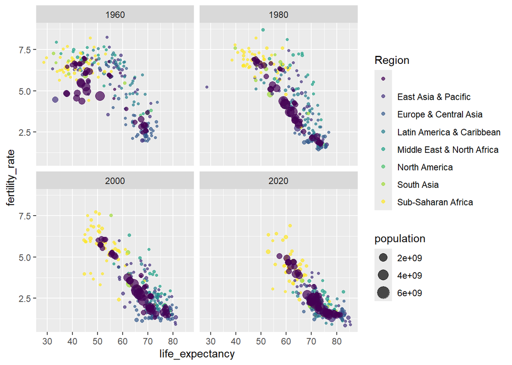

```r
ggplot(giant_plot, aes(x = life_expectancy, y = fertility_rate, color = Region, size = population)) +
  geom_point(alpha = 0.7) + facet_wrap(~ Year) + scale_color_viridis_d()
```

2. Fertility rate for most regions seems to have been decreasing 1980, the life expectancy of most regions seems to have been increasing for all of the regions as well.

```r
pop_by_region = final_joined_data %>%
  filter(!is.na(Region)) %>%
  group_by(Region, Year) %>%
  summarize(total_pop = sum(population, na.rm = TRUE))
```

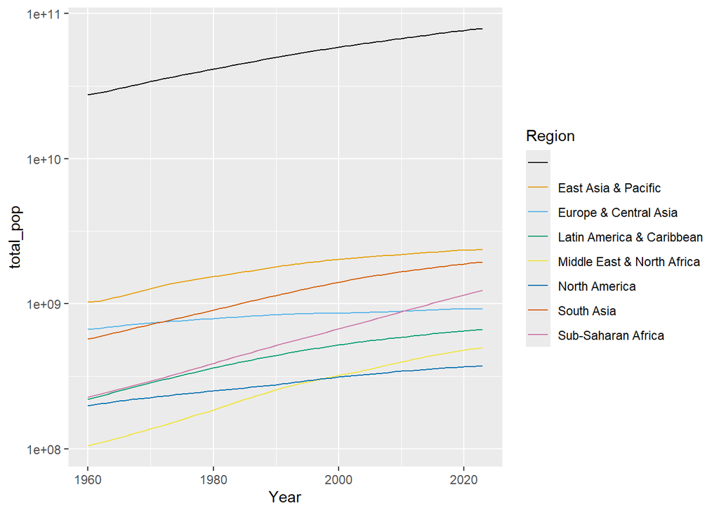

```r
ggplot(pop_by_region, aes(x = Year, y = total_pop, color = Region, group = Region)) + geom_line() + scale_y_log10() + scale_color_colorblind()
```